Skip to main content

# Meta-analysis in R: a worked example

- Show All Code
- Hide All Code
- View Source

BCG vaccine and tuberculosis: 13 randomised trials

Author

Dr Gurpreet

Published

November 18, 2026

## 1 Why this dataset?

`dat.bcg` (Colditz et al., *Clin Infect Dis* 1994) ships with **metafor**. It has 13 trials of BCG vaccination against tuberculosis, a binary outcome, and a lot of heterogeneity with a plausible explanation (distance from the equator). That makes it ideal for teaching every step: pooling, heterogeneity, small-study effects and sensitivity analysis.

```r
library(metafor)
library(tidyverse)

theme_set(theme_minimal(base_size = 12))

# Helper: metafor output -> tibble with snake_case names (ci.lb -> ci_lb)
tidy_mf <- \(x) x |>
  as.data.frame() |>
  as_tibble() |>
  rename_with(\(nm) str_replace_all(nm, "\\.", "_"))
```

## 2 The data

```r
bcg <- dat.bcg |>
  as_tibble() |>
  mutate(
    study  = str_c(author, ", ", year),
    n_vacc = tpos + tneg,
    n_ctrl = cpos + cneg
  ) |>
  select(trial, study, year, ablat, alloc,
         tpos, n_vacc, cpos, n_ctrl, tneg, cneg)

bcg |> select(study, ablat, alloc, tpos, n_vacc, cpos, n_ctrl)
```

| study | ablat | alloc | tpos | n_vacc | cpos | n_ctrl |
| --- | --- | --- | --- | --- | --- | --- |
| Aronson, 1948 | 44 | random | 4 | 123 | 11 | 139 |
| Ferguson & Simes, 1949 | 55 | random | 6 | 306 | 29 | 303 |
| Rosenthal et al, 1960 | 42 | random | 3 | 231 | 11 | 220 |
| Hart & Sutherland, 1977 | 52 | random | 62 | 13598 | 248 | 12867 |
| Frimodt-Moller et al, 1973 | 13 | alternate | 33 | 5069 | 47 | 5808 |
| Stein & Aronson, 1953 | 44 | alternate | 180 | 1541 | 372 | 1451 |
| Vandiviere et al, 1973 | 19 | random | 8 | 2545 | 10 | 629 |
| TPT Madras, 1980 | 13 | random | 505 | 88391 | 499 | 88391 |
| Coetzee & Berjak, 1968 | 27 | random | 29 | 7499 | 45 | 7277 |
| Rosenthal et al, 1961 | 42 | systematic | 17 | 1716 | 65 | 1665 |
| Comstock et al, 1974 | 18 | systematic | 186 | 50634 | 141 | 27338 |
| Comstock & Webster, 1969 | 33 | systematic | 5 | 2498 | 3 | 2341 |
| Comstock et al, 1976 | 33 | systematic | 27 | 16913 | 29 | 17854 |

`tpos`/`cpos` are TB cases in the vaccinated and control arms; `ablat` is the absolute latitude of the trial site.

## 3 Step 1: Effect size for each study

`escalc()` computes the **log risk ratio** (`yi`) and its **sampling variance** (`vi`). We analyse on the log scale and back-transform for reporting.

```r
bcg_es <- escalc(
  measure = "RR",
  ai = tpos, bi = tneg,   # vaccinated: events, non-events
  ci = cpos, di = cneg,   # control:    events, non-events
  data = bcg,
  slab = study
)

bcg_es |>
  as_tibble() |>
  mutate(
    rr    = exp(yi),
    lower = exp(yi - 1.96 * sqrt(vi)),
    upper = exp(yi + 1.96 * sqrt(vi))
  ) |>
  select(study, yi, vi, rr, lower, upper) |>
  mutate(across(where(is.numeric), \(x) round(x, 3)))
```

| study | yi | vi | rr | lower | upper |
| --- | --- | --- | --- | --- | --- |
| Aronson, 1948 | -0.889 | 0.326 | 0.411 | 0.134 | 1.257 |
| Ferguson & Simes, 1949 | -1.585 | 0.195 | 0.205 | 0.086 | 0.486 |
| Rosenthal et al, 1960 | -1.348 | 0.415 | 0.260 | 0.073 | 0.919 |
| Hart & Sutherland, 1977 | -1.442 | 0.020 | 0.237 | 0.179 | 0.312 |
| Frimodt-Moller et al, 1973 | -0.218 | 0.051 | 0.804 | 0.516 | 1.254 |
| Stein & Aronson, 1953 | -0.786 | 0.007 | 0.456 | 0.387 | 0.536 |
| Vandiviere et al, 1973 | -1.621 | 0.223 | 0.198 | 0.078 | 0.499 |
| TPT Madras, 1980 | 0.012 | 0.004 | 1.012 | 0.895 | 1.145 |
| Coetzee & Berjak, 1968 | -0.469 | 0.056 | 0.625 | 0.393 | 0.996 |
| Rosenthal et al, 1961 | -1.371 | 0.073 | 0.254 | 0.149 | 0.431 |
| Comstock et al, 1974 | -0.339 | 0.012 | 0.712 | 0.573 | 0.886 |
| Comstock & Webster, 1969 | 0.446 | 0.533 | 1.562 | 0.374 | 6.529 |
| Comstock et al, 1976 | -0.017 | 0.071 | 0.983 | 0.582 | 1.659 |

## 4 Step 2: Pool the studies

```r
res_fe <- rma(yi, vi, data = bcg_es, method = "EE")    # common (fixed) effect
res_re <- rma(yi, vi, data = bcg_es, method = "REML")  # random effects

res_re
```

```
Random-Effects Model (k = 13; tau^2 estimator: REML)

tau^2 (estimated amount of total heterogeneity): 0.3132 (SE = 0.1664)
tau (square root of estimated tau^2 value):      0.5597
I^2 (total heterogeneity / total variability):   92.22%
H^2 (total variability / sampling variability):  12.86

Test for Heterogeneity:
Q(df = 12) = 152.2330, p-val < .0001

Model Results:

estimate      se     zval    pval    ci.lb    ci.ub
 -0.7145  0.1798  -3.9744  <.0001  -1.0669  -0.3622  ***

---
Signif. codes:  0 '***' 0.001 '**' 0.01 '*' 0.05 '.' 0.1 ' ' 1
```

```r
pooled <- bind_rows(
  `Common effect`  = predict(res_fe, transf = exp) |> tidy_mf(),
  `Random effects` = predict(res_re, transf = exp) |> tidy_mf(),
  .id = "model"
) |>
  select(model, rr = pred, ci_lb, ci_ub, pi_lb, pi_ub)

pooled |> mutate(across(where(is.numeric), \(x) round(x, 2)))
```

| model | rr | ci_lb | ci_ub | pi_lb | pi_ub |
| --- | --- | --- | --- | --- | --- |
| Common effect | 0.65 | 0.60 | 0.7 | NA | NA |
| Random effects | 0.49 | 0.34 | 0.7 | 0.15 | 1.55 |

**NoteReading it**

Under the random-effects model, BCG vaccination is associated with a pooled RR of **0.49** (95% CI 0.34 to 0.70), roughly a 51% reduction in TB risk. The common-effect model gives a narrower and different answer because it ignores between-study variation. Here that assumption is clearly wrong (see Step 4).

## 5 Step 3: Forest plot

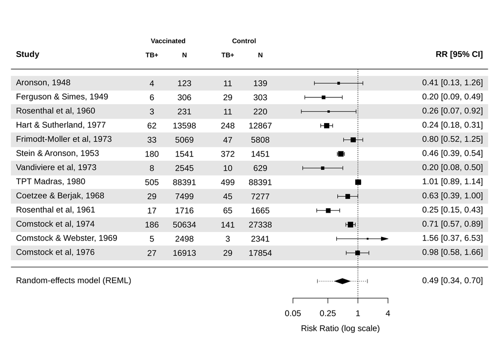

Figure 1: Forest plot, random-effects model, with 95% prediction interval

```r
forest(
  res_re,
  atransf   = exp,
  at        = log(c(0.05, 0.25, 1, 4)),
  xlim      = c(-16, 6),
  ilab      = cbind(bcg$tpos, bcg$n_vacc, bcg$cpos, bcg$n_ctrl),
  ilab.xpos = c(-9.5, -8, -6, -4.5),
  header    = c("Study", "RR [95% CI]"),
  addpred   = TRUE,
  shade     = TRUE,
  mlab      = "Random-effects model (REML)"
)
text(c(-9.5, -8, -6, -4.5), res_re$k + 2, c("TB+", "N", "TB+", "N"), font = 2, cex = 0.8)
text(c(-8.75, -5.25),       res_re$k + 3, c("Vaccinated", "Control"), font = 2, cex = 0.8)
```

**TipHow to read this plot**

- **Each row is one study.** The square is that study’s RR; the horizontal line is its 95% CI. An arrow means the CI runs off the scale.
- **Square size = weight** in the pooled analysis. Big squares pull the diamond towards themselves.
- **Vertical line at RR = 1** is the line of no effect. Left of it favours vaccination (fewer TB cases); right of it favours control.
- **The diamond** is the pooled RR: its centre is the point estimate and its width is the 95% CI.
- **The dotted line through the diamond** is the 95% **prediction interval**: the range in which the true effect of a *new* similar study is expected to lie.
- **The x-axis is logarithmic**, so RR 0.5 and RR 2 are equally far from 1.

**NoteWhat we infer from it**

- **Direction:** 11 of 13 trials lie left of 1; only TPT Madras (RR 1.01) and Comstock & Webster (RR 1.56) do not.
- **Precision varies:** 5 trials have a CI that crosses 1 on their own, yet the pooled diamond (0.49, 0.34 to 0.70) sits clearly left of 1. Pooling gives a precise answer that no single small trial could.
- **Visible heterogeneity (eyeball test):** many CIs do not overlap each other (e.g. Hart & Sutherland 0.24 vs TPT Madras 1.01). Studies are not estimating one common effect.
- **Weights are fairly even** (3.82% to 10.19%) because τ² is large. Under a common-effect model TPT Madras alone would carry 41.40% of the weight, versus 10.19% here.
- **Prediction interval crosses 1** (0.15 to 1.55): BCG works *on average*, but in some settings it may give little or no protection. Report both the CI and the PI.

## 6 Step 4: Heterogeneity

```r
tibble(
  statistic = c("Q", "df", "p (Q)", "tau^2", "tau", "I^2 (%)", "H^2"),
  value     = c(res_re$QE, res_re$k - 1, res_re$QEp,
                res_re$tau2, sqrt(res_re$tau2), res_re$I2, res_re$H2)
) |>
  mutate(value = if_else(statistic == "p (Q)",
                         format.pval(value, eps = 1e-4),
                         as.character(round(value, 2))))
```

| statistic | value |
| --- | --- |
| Q | 152.23 |
| df | 12 |
| p (Q) | < 1e-04 |
| tau^2 | 0.31 |
| tau | 0.56 |
| I^2 (%) | 92.22 |
| H^2 | 12.86 |

Confidence intervals for the heterogeneity parameters:

```r
confint(res_re)
```

```
       estimate   ci.lb   ci.ub
tau^2    0.3132  0.1197  1.1115
tau      0.5597  0.3460  1.0543
I^2(%)  92.2214 81.9177 97.6781
H^2     12.8558  5.5303 43.0680
```

**ImportantReading it**

- **Q test**: rejects homogeneity (p < 0.0001), but it has low power with few studies and too much power with many, so do not rely on it alone.
- **I² = 92%**: the share of total variability due to real differences between studies, not chance. It is a *proportion*, not an absolute amount.
- **τ² = 0.31**: the *absolute* between-study variance on the log RR scale.
- **Prediction interval 0.15 to 1.55**: a new trial in a new setting could plausibly find anything from a large benefit to no benefit or even harm. This is often the most useful number for clinicians.

### 6.1 Explaining heterogeneity: meta-regression on latitude

```r
res_mr <- rma(yi, vi, mods = ~ ablat, data = bcg_es, method = "REML")
res_mr
```

```
Mixed-Effects Model (k = 13; tau^2 estimator: REML)

tau^2 (estimated amount of residual heterogeneity):     0.0764 (SE = 0.0591)
tau (square root of estimated tau^2 value):             0.2763
I^2 (residual heterogeneity / unaccounted variability): 68.39%
H^2 (unaccounted variability / sampling variability):   3.16
R^2 (amount of heterogeneity accounted for):            75.62%

Test for Residual Heterogeneity:
QE(df = 11) = 30.7331, p-val = 0.0012

Test of Moderators (coefficient 2):
QM(df = 1) = 16.3571, p-val < .0001

Model Results:

         estimate      se     zval    pval    ci.lb    ci.ub
intrcpt    0.2515  0.2491   1.0095  0.3127  -0.2368   0.7397
ablat     -0.0291  0.0072  -4.0444  <.0001  -0.0432  -0.0150  ***

---
Signif. codes:  0 '***' 0.001 '**' 0.01 '*' 0.05 '.' 0.1 ' ' 1
```

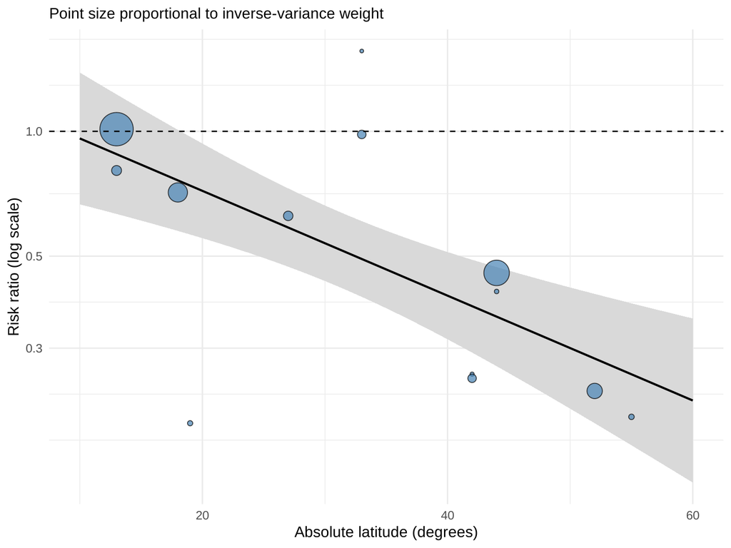

Figure 2: Bubble plot: BCG efficacy improves further from the equator

```r
lat_grid <- tibble(ablat = seq(10, 60, by = 1))

lat_pred <- predict(res_mr, newmods = lat_grid$ablat, transf = exp) |>
  tidy_mf() |>
  bind_cols(lat_grid)

bcg_es |>
  as_tibble() |>
  mutate(rr = exp(yi), weight = 1 / vi) |>
  ggplot(aes(ablat, rr)) +
  geom_ribbon(data = lat_pred, aes(y = pred, ymin = ci_lb, ymax = ci_ub),
              fill = "grey85") +
  geom_line(data = lat_pred, aes(y = pred), linewidth = 0.8) +
  geom_point(aes(size = weight), shape = 21, fill = "steelblue", alpha = 0.7) +
  geom_hline(yintercept = 1, linetype = "dashed") +
  scale_y_log10() +
  scale_size_area(max_size = 12, guide = "none") +
  labs(x = "Absolute latitude (degrees)", y = "Risk ratio (log scale)",
       subtitle = "Point size proportional to inverse-variance weight")
```

**TipHow to read this plot**

- **Each bubble is one trial**, placed at its latitude (x) and its RR (y, log scale). **Bubble size = weight** in the meta-regression.
- **The solid line** is the fitted meta-regression; **the grey band** is its 95% CI.
- **Dashed line at RR = 1** is no effect. Where the band sits below it, the model predicts a protective effect.
- A sloping line means the moderator explains part of the heterogeneity; a flat line means it does not.

**NoteWhat we infer from it**

- **Clear dose-response with latitude:** each extra degree from the equator multiplies the RR by 0.97, i.e. about 2.9% more protection per degree (p < 0.0001).
- **Near the equator BCG shows little effect** (trials at 13-19°, such as TPT Madras and Frimodt-Moller, sit near RR = 1). **Far from the equator it is highly protective** (RR around 0.2-0.3 above 50°).
- Latitude explains about **76%** of the between-study variance (R²), and residual I² falls from 92% to 68%. Heterogeneity is largely *explained*, not just noise.
- **Caution:** this is an observational association *across* studies (ecological). Latitude is a proxy for something else, plausibly prior exposure to environmental mycobacteria. With 13 studies, one moderator is the most the data can support (about 10 studies per covariate).

## 7 Step 5: Funnel plot

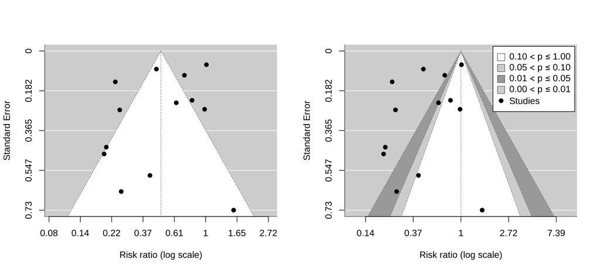

Figure 3: Funnel plot (left) and contour-enhanced funnel plot (right)

```r
par(mfrow = c(1, 2))
funnel(res_re, atransf = exp, xlab = "Risk ratio (log scale)")
funnel(res_re, level = c(90, 95, 99),
       shade = c("white", "grey80", "grey60"),
       refline = 0, legend = TRUE,
       atransf = exp, xlab = "Risk ratio (log scale)")
par(mfrow = c(1, 1))
```

**TipHow to read this plot**

- **x-axis:** each study’s effect (RR, log scale). **y-axis:** its standard error, *inverted*, so large precise studies are at the top and small imprecise ones at the bottom.
- **Vertical line:** the pooled estimate. **Triangle (left panel):** where 95% of studies should fall if there were no bias and no heterogeneity.
- **Expected shape:** a symmetrical inverted funnel. Big studies cluster tightly near the top; small studies scatter widely but *evenly on both sides* at the bottom.
- **Asymmetry** (a gap in one bottom corner) suggests small studies with “unfavourable” results are missing.
- **Contour-enhanced panel (right):** the reference line is RR = 1 and the shading marks where results are statistically significant (grey zones: p < 0.10, < 0.05, < 0.01). If the gap is in the white (non-significant) zone, publication bias is a plausible cause. If it is in a significant zone, look for other causes (heterogeneity, small-trial quality, chance).

**NoteWhat we infer from it**

- **The large trials** (TPT Madras, Stein & Aronson, Comstock 1974, Hart & Sutherland) sit at the top but are **spread widely left to right**. That spread among precise studies is heterogeneity, not publication bias.
- **Many points fall outside the triangle.** Expected when I² is 92%: the triangle assumes a single common effect.
- **Small trials at the bottom mostly lie to the left** (strong benefit), with one on the right (Comstock & Webster, RR 1.56). There is only a mild hint of asymmetry.
- **In the contour panel**, the small trials sit in both shaded and white zones, so there is no clear sign that non-significant studies are missing.
- **Bottom line:** the visual impression is “some asymmetry, most likely driven by heterogeneity (latitude)”. We check this formally next.

## 8 Step 6: Egger’s test and friends

```r
egger <- regtest(res_re, model = "lm", predictor = "sei")  # classic Egger
egger
```

```
Regression Test for Funnel Plot Asymmetry

Model:     weighted regression with multiplicative dispersion
Predictor: standard error

Test for Funnel Plot Asymmetry: t = -1.4013, df = 11, p = 0.1887
Limit Estimate (as sei -> 0):   b = -0.1909 (CI: -0.6753, 0.2935)
```

```r
ranktest(res_re)
```

```
Rank Correlation Test for Funnel Plot Asymmetry

Kendall's tau = 0.0256, p = 0.9524
```

```r
res_tf <- trimfill(res_re)
res_tf
```

```
Estimated number of missing studies on the right side: 1 (SE = 2.4528)

Random-Effects Model (k = 14; tau^2 estimator: REML)

tau^2 (estimated amount of total heterogeneity): 0.3313 (SE = 0.1701)
tau (square root of estimated tau^2 value):      0.5756
I^2 (total heterogeneity / total variability):   92.14%
H^2 (total variability / sampling variability):  12.72

Test for Heterogeneity:
Q(df = 13) = 154.6750, p-val < .0001

Model Results:

estimate      se     zval    pval    ci.lb    ci.ub
 -0.6571  0.1785  -3.6805  0.0002  -1.0070  -0.3072  ***

---
Signif. codes:  0 '***' 0.001 '**' 0.01 '*' 0.05 '.' 0.1 ' ' 1
```

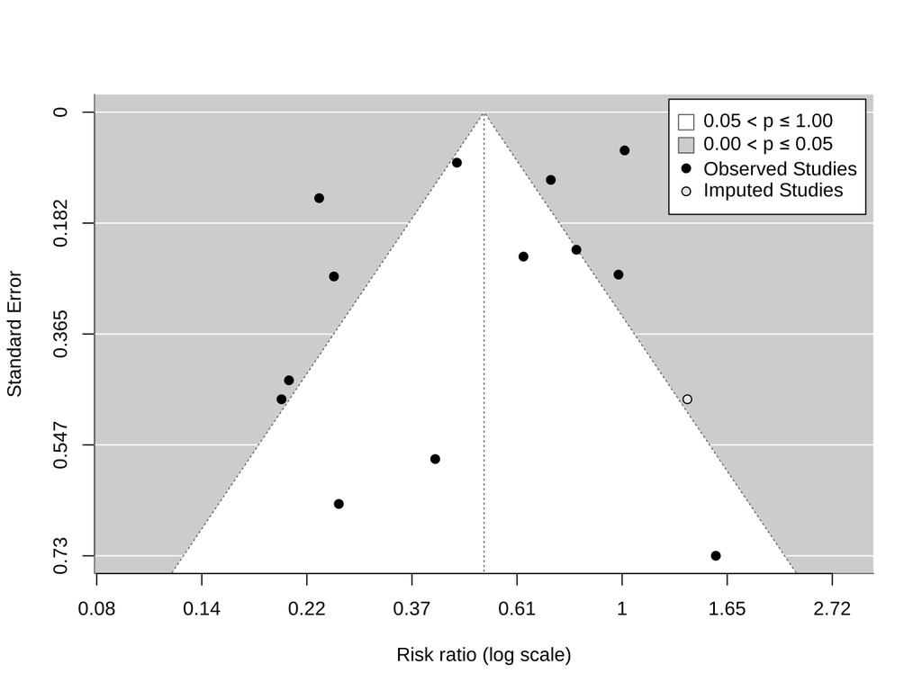

Figure 4: Trim-and-fill: imputed study shown as an open circle

```r
funnel(res_tf, atransf = exp, legend = TRUE, xlab = "Risk ratio (log scale)")
```

**WarningReading it**

**How to read the tests:** Egger’s test regresses the effect on its standard error. A slope (here t = -1.40) significantly different from 0 means small studies show systematically different results from large ones. Begg’s test asks the same question with rank correlation. **How to read the trim-and-fill funnel:** open circles are the *imputed* “missing” studies, mirrored from the opposite side; the vertical line is the adjusted estimate.

**What we infer:** Egger’s test p = 0.19 and Begg’s test p = 0.95: no strong evidence of small-study effects. Trim-and-fill imputes 1 study on the right side (towards no effect) and moves the pooled RR only from 0.49 to 0.52 (95% CI 0.37 to 0.74). The conclusion that BCG protects is unchanged. Remember:

- With fewer than 10 studies, do not test for asymmetry (Cochrane Handbook).
- Asymmetry ≠ publication bias. With I² this high, heterogeneity alone can distort the funnel.
- Trim-and-fill is a sensitivity analysis, not a correction.

## 9 Step 7: Leave-one-out sensitivity analysis

```r
loo <- leave1out(res_re, transf = exp) |>
  tidy_mf() |>
  mutate(study = bcg$study) |>
  select(omitted = study, rr = estimate, ci_lb, ci_ub, I2, tau2)

loo |> mutate(across(where(is.numeric), \(x) round(x, 2)))
```

| omitted | rr | ci_lb | ci_ub | I2 | tau2 |
| --- | --- | --- | --- | --- | --- |
| Aronson, 1948 | 0.49 | 0.34 | 0.72 | 93.23 | 0.34 |
| Ferguson & Simes, 1949 | 0.52 | 0.36 | 0.74 | 92.25 | 0.29 |
| Rosenthal et al, 1960 | 0.50 | 0.35 | 0.73 | 92.94 | 0.32 |
| Hart & Sutherland, 1977 | 0.53 | 0.38 | 0.75 | 90.41 | 0.26 |
| Frimodt-Moller et al, 1973 | 0.47 | 0.32 | 0.68 | 92.76 | 0.33 |
| Stein & Aronson, 1953 | 0.49 | 0.33 | 0.73 | 90.91 | 0.36 |
| Vandiviere et al, 1973 | 0.52 | 0.36 | 0.74 | 92.28 | 0.29 |
| TPT Madras, 1980 | 0.45 | 0.32 | 0.64 | 87.03 | 0.27 |
| Coetzee & Berjak, 1968 | 0.48 | 0.32 | 0.70 | 93.21 | 0.35 |
| Rosenthal et al, 1961 | 0.52 | 0.36 | 0.75 | 92.23 | 0.30 |
| Comstock et al, 1974 | 0.47 | 0.32 | 0.69 | 91.81 | 0.34 |
| Comstock & Webster, 1969 | 0.47 | 0.33 | 0.67 | 92.68 | 0.31 |
| Comstock et al, 1976 | 0.46 | 0.32 | 0.66 | 92.34 | 0.30 |

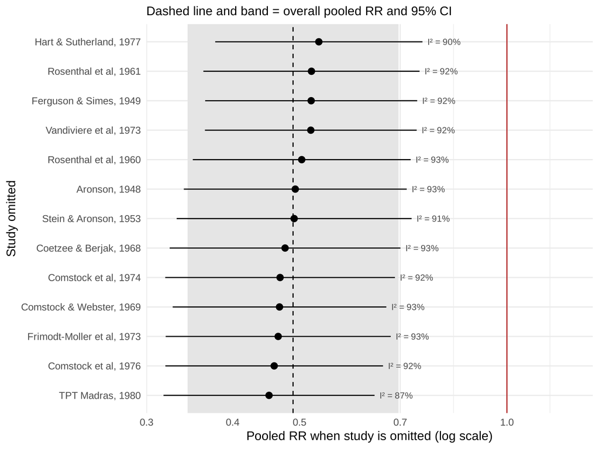

Figure 5: Pooled RR after omitting each study in turn

```r
pooled_rr <- exp(res_re$b[1])

loo |>
  mutate(omitted = fct_reorder(omitted, rr)) |>
  ggplot(aes(rr, omitted)) +
  annotate("rect", xmin = exp(res_re$ci.lb), xmax = exp(res_re$ci.ub),
           ymin = -Inf, ymax = Inf, fill = "grey90") +
  geom_vline(xintercept = pooled_rr, linetype = "dashed") +
  geom_vline(xintercept = 1, colour = "firebrick") +
  geom_pointrange(aes(xmin = ci_lb, xmax = ci_ub)) +
  geom_text(aes(x = ci_ub, label = str_c("I² = ", round(I2), "%")),
            hjust = -0.15, size = 3, colour = "grey30") +
  scale_x_log10(breaks = c(0.3, 0.4, 0.5, 0.7, 1),
                expand = expansion(mult = c(0.05, 0.25))) +
  labs(x = "Pooled RR when study is omitted (log scale)", y = "Study omitted",
       subtitle = "Dashed line and band = overall pooled RR and 95% CI")
```

**TipHow to read this plot**

- **Each row is the meta-analysis re-run without one study** (named on the y-axis). The dot is the new pooled RR and the line is its 95% CI.
- **Dashed line and grey band:** the original pooled RR and CI with all studies. **Red line:** RR = 1 (no effect).
- **Rows are sorted** by the new pooled RR, so the top and bottom rows are the studies whose removal moves the answer most.
- **Labels on the right** show the I² after removal. A big drop marks a study that contributes a lot of heterogeneity.
- **What to look for:** does any omission push the estimate outside the grey band, or make the CI cross the red line? If so, the result depends on that one study.

**NoteWhat we infer from it**

- Omitting any single trial moves the pooled RR only between 0.45 and 0.53. All dots stay inside the original CI band and **every CI stays clear of 1**. The conclusion is **robust** to any one study.
- **TPT Madras** (largest trial, null result) is the most influential on the *heterogeneity*: dropping it lowers I² to 87% and gives the most favourable estimate (0.45).
- **Hart & Sutherland** (large, very protective) pulls the other way: dropping it gives the least favourable estimate (0.53).
- **I² stays above 85% whichever study is removed:** heterogeneity is not caused by one outlier. It is a feature of the whole evidence base, which is why the meta-regression on latitude matters.

### 9.1 Influence diagnostics

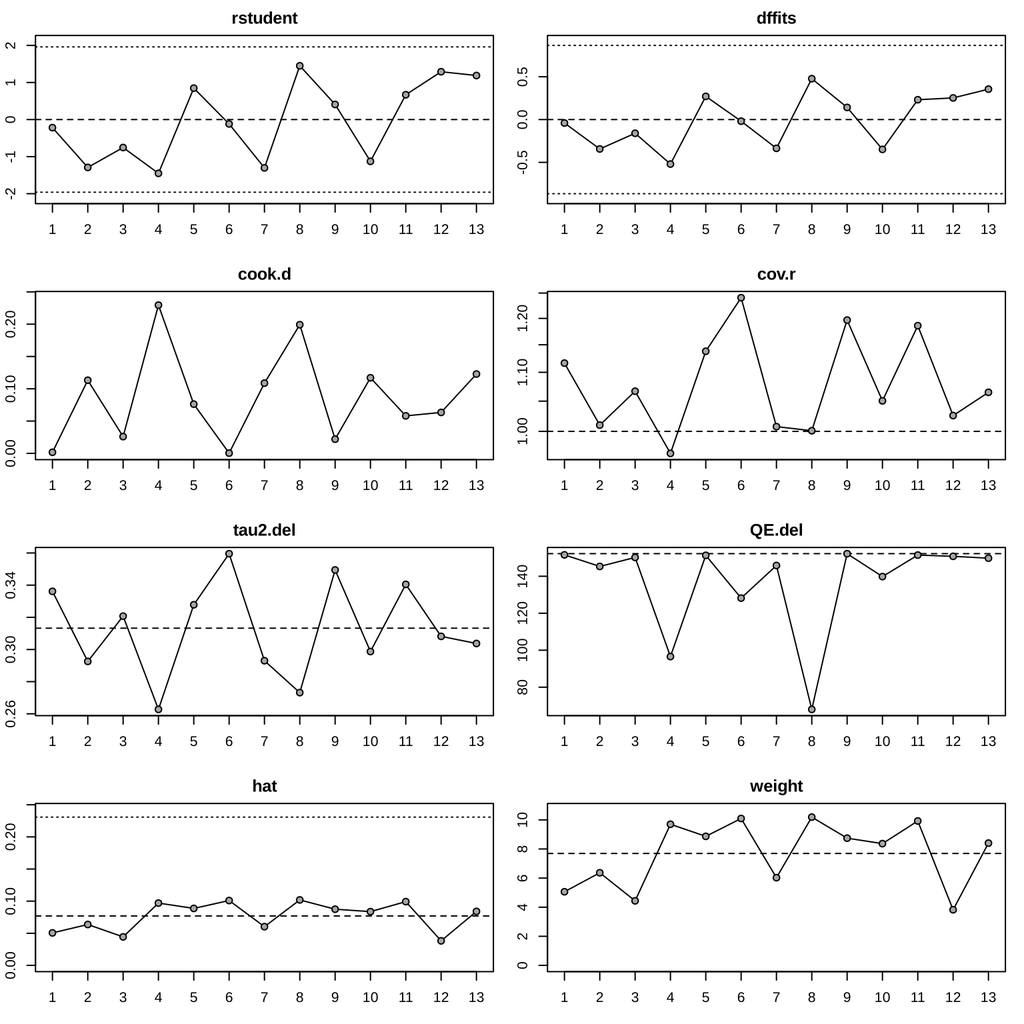

Figure 6: Influence diagnostics (Viechtbauer & Cheung, 2010)

```r
inf_re <- influence(res_re)
inf_re |> plot()
```

**TipHow to read this plot**

Eight panels, one point per study (x-axis = study number, in the order of the forest plot):

- **rstudent:** standardised residual. Values beyond ±2 to 3 mark outliers.
- **dffits** and **cook.d:** how much the pooled estimate changes when the study is removed. Large values mean influential.
- **cov.r:** below 1 means removing the study makes the estimate *more* precise.
- **tau2.del** and **QE.del:** τ² and Q after removing the study. A big drop marks a source of heterogeneity.
- **hat** and **weight:** leverage and weight of each study.
- **Red points** are studies flagged as influential by the combined rules of Viechtbauer & Cheung (2010).

**NoteWhat we infer from it**

- **0 studies are flagged as influential**; no residual exceeds ±2.
- The highest Cook’s distances belong to **Hart & Sutherland** (0.23) and **TPT Madras** (0.20). These two also cause the largest drops in Q (QE.del 97 and 68 vs 152 overall).
- Together this agrees with leave-one-out: two large trials at opposite extremes drive the heterogeneity, but neither alone changes the conclusion.

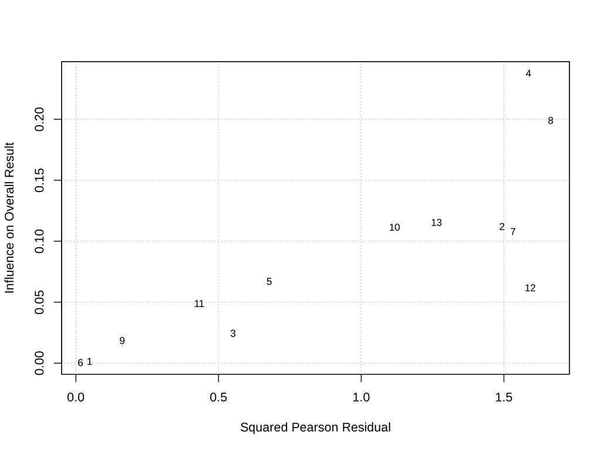

Figure 7: Baujat plot: contribution to heterogeneity (x) vs influence on the pooled result (y)

```r
baujat(res_re)
```

**TipHow to read this plot**

- **x-axis:** how much each study contributes to the overall heterogeneity (its share of Cochran’s Q).
- **y-axis:** how much the pooled estimate changes when that study is removed (influence on the result).
- **Top-right corner** = studies that both add heterogeneity *and* move the result. These deserve a closer look (population, design, risk of bias).
- **Bottom-left** = studies that agree with the rest and have little leverage.

**NoteWhat we infer from it**

- **Hart & Sutherland (study 4)** and **TPT Madras (study 8)** sit in the top-right: they are the main drivers of heterogeneity and of the pooled estimate. They lie at opposite latitudes (52° vs 13°), which again points to latitude as the explanation.
- **Comstock & Webster, Vandiviere, Ferguson & Simes, Comstock 1976 and Rosenthal 1961** add heterogeneity but have moderate influence.
- **Stein & Aronson and Aronson** sit near the origin: consistent with the pooled result.

## 10 Summary for the slide

```r
tibble(
  item = c("Studies (k)", "Pooled RR (RE, 95% CI)", "95% prediction interval",
           "I²", "τ²", "Egger p", "Leave-one-out RR range"),
  result = c(
    res_re$k,
    str_glue("{f2(re$rr)} ({f2(re$ci_lb)} to {f2(re$ci_ub)})"),
    str_glue("{f2(re$pi_lb)} to {f2(re$pi_ub)}"),
    str_c(round(res_re$I2), "%"),
    f2(res_re$tau2),
    f2(egger$pval),
    str_glue("{f2(min(loo$rr))} to {f2(max(loo$rr))}")
  )
)
```

| item | result |
| --- | --- |
| Studies (k) | 13 |
| Pooled RR (RE, 95% CI) | 0.49 (0.34 to 0.70) |
| 95% prediction interval | 0.15 to 1.55 |
| I² | 92% |
| τ² | 0.31 |
| Egger p | 0.19 |
| Leave-one-out RR range | 0.45 to 0.53 |

## 11 Appendix: the same analysis with the **meta** package

The *Meta-Analysis with R* book (Schwarzer, Carpenter & Rücker, 2015) uses **meta**. The equivalent calls are below (not run here).

```r
library(meta)

m <- metabin(
  event.e = tpos, n.e = n_vacc,
  event.c = cpos, n.c = n_ctrl,
  studlab = study, data = bcg,
  sm = "RR", method.tau = "REML",
  common = TRUE, random = TRUE, prediction = TRUE
)

summary(m)                                   # pooled RR, Q, I², τ²
forest(m, sortvar = TE)                      # forest plot
funnel(m, contour = c(0.9, 0.95, 0.99))      # contour-enhanced funnel
metabias(m, method.bias = "Egger")           # Egger's test
trimfill(m)                                  # trim-and-fill
metainf(m, pooled = "random") |> forest()    # leave-one-out
metareg(m, ~ ablat)                          # meta-regression
```